# Chapter - 2

**Q8. This exercise relates to the College data set, which can be found in the file College.csv on the book website. It contains a number of variables for 777 different universities and colleges in the US**

1. Use the read.csv() function to read the data into R. Call the loaded data “college”. Make sure that you have the directory set to the correct location for the data.

```r
college <- read.csv("College.csv")
```

2. Look at the data using the fix() function. You should notice that the first column is just the name of each university. We don’t really want R to treat this as data. However, it may be handy to have these names for later.

```r
head(college[, 1:5])
```

|  | X | Private | Apps | Accept | Enroll |
| --- | --- | --- | --- | --- | --- |
| 1 | Abilene Christian University | Yes | 1660 | 1232 | 721 |
| 2 | Adelphi University | Yes | 2186 | 1924 | 512 |
| 3 | Adrian College | Yes | 1428 | 1097 | 336 |
| 4 | Agnes Scott College | Yes | 417 | 349 | 137 |
| 5 | Alaska Pacific University | Yes | 193 | 146 | 55 |
| 6 | Albertson College | Yes | 587 | 479 | 158 |

```r
rownames <- college[, 1]
college <- college[, -1]
head(college[, 1:5])
```

|  | Private | Apps | Accept | Enroll | Top10perc |
| --- | --- | --- | --- | --- | --- |
| 1 | Yes | 1660 | 1232 | 721 | 23 |
| 2 | Yes | 2186 | 1924 | 512 | 16 |
| 3 | Yes | 1428 | 1097 | 336 | 22 |
| 4 | Yes | 417 | 349 | 137 | 60 |
| 5 | Yes | 193 | 146 | 55 | 16 |
| 6 | Yes | 587 | 479 | 158 | 38 |

1. Use the summary() function to produce a numerical summary of the variables in the data set.

```r
summary(college)
```

```
   Private               Apps           Accept
 Length:777         Min.   :   81   Min.   :   72
 Class :character   1st Qu.:  776   1st Qu.:  604
 Mode  :character   Median : 1558   Median : 1110
                    Mean   : 3002   Mean   : 2019
                    3rd Qu.: 3624   3rd Qu.: 2424
                    Max.   :48094   Max.   :26330
     Enroll       Top10perc       Top25perc
 Min.   :  35   Min.   : 1.00   Min.   :  9.0
 1st Qu.: 242   1st Qu.:15.00   1st Qu.: 41.0
 Median : 434   Median :23.00   Median : 54.0
 Mean   : 780   Mean   :27.56   Mean   : 55.8
 3rd Qu.: 902   3rd Qu.:35.00   3rd Qu.: 69.0
 Max.   :6392   Max.   :96.00   Max.   :100.0
  F.Undergrad     P.Undergrad         Outstate
 Min.   :  139   Min.   :    1.0   Min.   : 2340
 1st Qu.:  992   1st Qu.:   95.0   1st Qu.: 7320
 Median : 1707   Median :  353.0   Median : 9990
 Mean   : 3700   Mean   :  855.3   Mean   :10441
 3rd Qu.: 4005   3rd Qu.:  967.0   3rd Qu.:12925
 Max.   :31643   Max.   :21836.0   Max.   :21700
   Room.Board       Books           Personal
 Min.   :1780   Min.   :  96.0   Min.   : 250
 1st Qu.:3597   1st Qu.: 470.0   1st Qu.: 850
 Median :4200   Median : 500.0   Median :1200
 Mean   :4358   Mean   : 549.4   Mean   :1341
 3rd Qu.:5050   3rd Qu.: 600.0   3rd Qu.:1700
 Max.   :8124   Max.   :2340.0   Max.   :6800
      PhD            Terminal       S.F.Ratio
 Min.   :  8.00   Min.   : 24.0   Min.   : 2.50
 1st Qu.: 62.00   1st Qu.: 71.0   1st Qu.:11.50
 Median : 75.00   Median : 82.0   Median :13.60
 Mean   : 72.66   Mean   : 79.7   Mean   :14.09
 3rd Qu.: 85.00   3rd Qu.: 92.0   3rd Qu.:16.50
 Max.   :103.00   Max.   :100.0   Max.   :39.80
  perc.alumni        Expend        Grad.Rate
 Min.   : 0.00   Min.   : 3186   Min.   : 10.00
 1st Qu.:13.00   1st Qu.: 6751   1st Qu.: 53.00
 Median :21.00   Median : 8377   Median : 65.00
 Mean   :22.74   Mean   : 9660   Mean   : 65.46
 3rd Qu.:31.00   3rd Qu.:10830   3rd Qu.: 78.00
 Max.   :64.00   Max.   :56233   Max.   :118.00
```

ii.Use the pairs() function to produce a scatterplot matrix of the first ten columns or variables of the data.

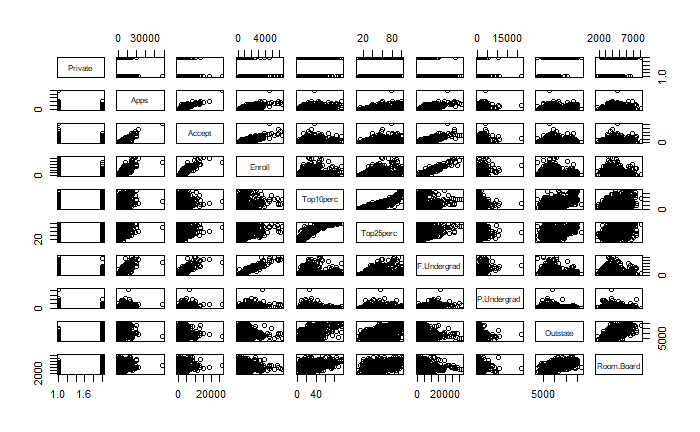

```r
college[,1] = as.numeric(factor(college[,1]))
pairs(college[,1:10])
```

3. Use the plot() function to produce side-by-side boxplots of “Outstate” versus “Private”.

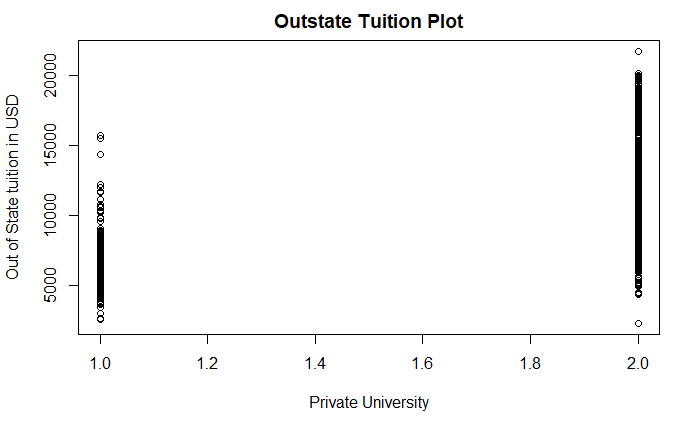

```r
plot(college$Private, college$Outstate, xlab = "Private University", ylab ="Out of State tuition in USD", main = "Outstate Tuition Plot")
```

4. Create a new qualitative variable, called “Elite”, by binning the “Top10perc” variable. Use the summary() function to see how many elite universities there are. Now use the plot() function to produce side-by-side boxplots of “Outstate” versus “Elite”.

```r
Elite <- rep("No", nrow(college))
Elite[college$Top10perc > 50] <- "Yes"
Elite <- as.factor(Elite)
college$Elite <- Elite
summary(college$Elite)
```

```
 No Yes
699  78
```

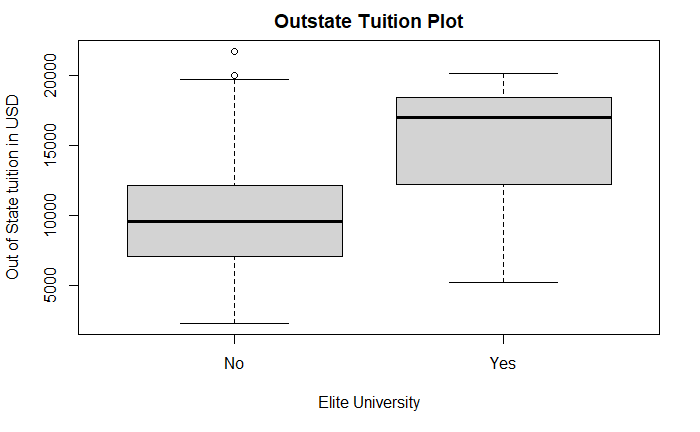

```r
plot(college$Elite, college$Outstate, xlab = "Elite University", ylab ="Out of State tuition in USD", main = "Outstate Tuition Plot")
```

22. Use the hist() function to produce some histograms with numbers of bins for a few of the quantitative variables.

```r
par(mfrow = c(2,2))
hist(college$Books, col = 2, xlab = "Books", ylab = "Count")
hist(college$PhD, col = 3, xlab = "PhD", ylab = "Count")
```

[figure not shown]

```r
hist(college$Grad.Rate, col = 4, xlab = "Grad Rate", ylab = "Count")
hist(college$perc.alumni, col = 6, xlab = "% alumni", ylab = "Count")
```

6. Continue exploring the data, and provide a brief summary of what you discover.

```r
summary(college$PhD)
```

```
   Min. 1st Qu.  Median    Mean 3rd Qu.    Max.
   8.00   62.00   75.00   72.66   85.00  103.00
```

It is a little weird to have universities with 103% of faculty with Phd’s, let us see how many universities have this percentage and their names.

```r
weird.phd <- college[college$PhD == 103, ]
nrow(weird.phd)
```

```
[1] 1
```

```r
rownames[as.numeric(rownames(weird.phd))]
```

```
[1] "Texas A&M University at Galveston"
```

**Q9. This exercise involves the “Auto” data set studied in the lab. Make sure the missing values have been removed from the data.**

1. Which of the predictors are quantitative, and which are qualitative ?

```r
auto <- read.csv("Auto.csv", na.strings = "?")
auto <- na.omit(auto)
str(auto)
```

```
'data.frame':   392 obs. of  9 variables:
 $ mpg         : num  18 15 18 16 17 15 14 14 14 15 ...
 $ cylinders   : int  8 8 8 8 8 8 8 8 8 8 ...
 $ displacement: num  307 350 318 304 302 429 454 440 455 390 ...
 $ horsepower  : int  130 165 150 150 140 198 220 215 225 190 ...
 $ weight      : int  3504 3693 3436 3433 3449 4341 4354 4312 4425 3850 ...
 $ acceleration: num  12 11.5 11 12 10.5 10 9 8.5 10 8.5 ...
 $ year        : int  70 70 70 70 70 70 70 70 70 70 ...
 $ origin      : int  1 1 1 1 1 1 1 1 1 1 ...
 $ name        : chr  "chevrolet chevelle malibu" "buick skylark 320" "plymouth satellite" "amc rebel sst" ...
 - attr(*, "na.action")= 'omit' Named int [1:5] 33 127 331 337 355
  ..- attr(*, "names")= chr [1:5] "33" "127" "331" "337" ...
```

2. What is the range of each quantitative predictor ?

```r
summary(auto[, -c(4, 9)])
```

```
      mpg          cylinders      displacement
 Min.   : 9.00   Min.   :3.000   Min.   : 68.0
 1st Qu.:17.00   1st Qu.:4.000   1st Qu.:105.0
 Median :22.75   Median :4.000   Median :151.0
 Mean   :23.45   Mean   :5.472   Mean   :194.4
 3rd Qu.:29.00   3rd Qu.:8.000   3rd Qu.:275.8
 Max.   :46.60   Max.   :8.000   Max.   :455.0
     weight      acceleration        year
 Min.   :1613   Min.   : 8.00   Min.   :70.00
 1st Qu.:2225   1st Qu.:13.78   1st Qu.:73.00
 Median :2804   Median :15.50   Median :76.00
 Mean   :2978   Mean   :15.54   Mean   :75.98
 3rd Qu.:3615   3rd Qu.:17.02   3rd Qu.:79.00
 Max.   :5140   Max.   :24.80   Max.   :82.00
     origin
 Min.   :1.000
 1st Qu.:1.000
 Median :1.000
 Mean   :1.577
 3rd Qu.:2.000
 Max.   :3.000
```

3. What is the mean and standard deviation of each quantitative predictor ?

```r
sapply(auto[, -c(4, 9)], mean)
```

```
         mpg    cylinders displacement       weight
   23.445918     5.471939   194.411990  2977.584184
acceleration         year       origin
   15.541327    75.979592     1.576531
```

```r
sapply(auto[, -c(4, 9)], sd)
```

```
         mpg    cylinders displacement       weight
   7.8050075    1.7057832  104.6440039  849.4025600
acceleration         year       origin
   2.7588641    3.6837365    0.8055182
```

4. Now remove the 10th through 85th observations. What is the range, mean, and standard deviation of each predictor in the subset of the data that remains ?

```r
subset <- auto[-c(10:85), -c(4,9)]
sapply(subset, range)
```

```
      mpg cylinders displacement weight acceleration
[1,] 11.0         3           68   1649          8.5
[2,] 46.6         8          455   4997         24.8
     year origin
[1,]   70      1
[2,]   82      3
```

```r
sapply(subset, mean)
```

```
         mpg    cylinders displacement       weight
   24.404430     5.373418   187.240506  2935.971519
acceleration         year       origin
   15.726899    77.145570     1.601266
```

```r
sapply(subset, sd)
```

```
         mpg    cylinders displacement       weight
    7.867283     1.654179    99.678367   811.300208
acceleration         year       origin
    2.693721     3.106217     0.819910
```

5. Using the full data set, investigate the predictors graphically, using scatterplots or other tools of your choice. Create some plots highlighting the relationships among the predictors. Comment on your findings.

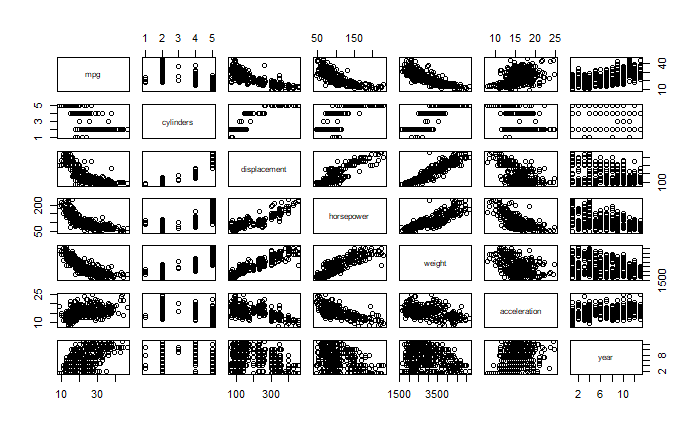

```r
auto$cylinders <- as.factor(auto$cylinders)
auto$year <- as.factor(auto$year)
auto$origin <- as.factor(auto$origin)
pairs(auto[,1:7])
```

6. Suppose that we wish to predict gas mileage (“mpg”) on the basis of other variables. Do your plots suggest that any of the other variables might be useful in predicting “mpg” ?

```r
auto$horsepower <- as.numeric(auto$horsepower)
cor(auto$weight, auto$horsepower)
```

```
[1] 0.8645377
```

```r
cor(auto$weight, auto$displacement)
```

```
[1] 0.9329944
```

```r
cor(auto$displacement, auto$horsepower)
```

```
[1] 0.897257
```

*Q10. This exercise involves the “Boston” housing data set.*

1. To begin, load in the “Boston” data set.

```r
library(MASS)
Boston$chas <- as.factor(Boston$chas)
nrow(Boston)
```

```
[1] 506
```

```r
ncol(Boston)
```

```
[1] 14
```

2. Make some pairwise scatterplots of the predictors in this data set.

```r
par(mfrow = c(2, 2))
plot(Boston$nox, Boston$crim)
plot(Boston$rm, Boston$crim)
```

[figure not shown]

```r
plot(Boston$age, Boston$crim)
plot(Boston$dis, Boston$crim)
```

3. Are any of the predictors associated with per capita crime rate ?

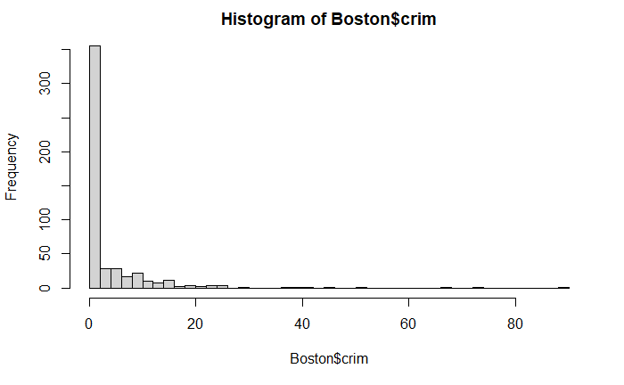

```r
hist(Boston$crim, breaks = 50)
```

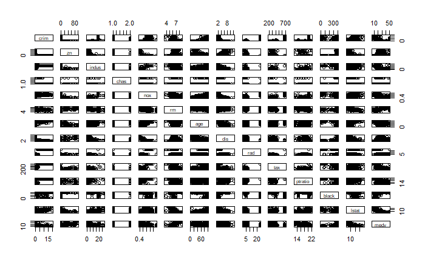

```r
pairs(Boston[Boston$crim < 20, ])
```

There may be a relationship between crim and nox, rm, age, dis, lstat and medv.

4. Do any of the suburbs of Boston appear to have particularly high crime rates ? Tax rates ? Pupil-teacher ratios ?

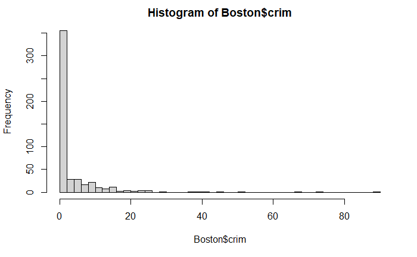

```r
hist(Boston$crim, breaks = 50)
```

```r
nrow(Boston[Boston$crim > 20, ])
```

```
[1] 18
```

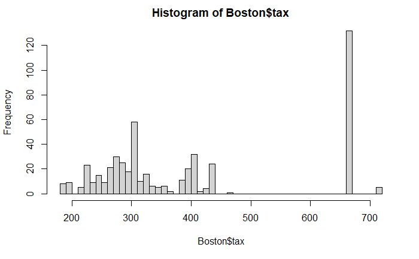

```r
hist(Boston$tax, breaks = 50)
```

```r
nrow(Boston[Boston$tax == 666, ])
```

```
[1] 132
```

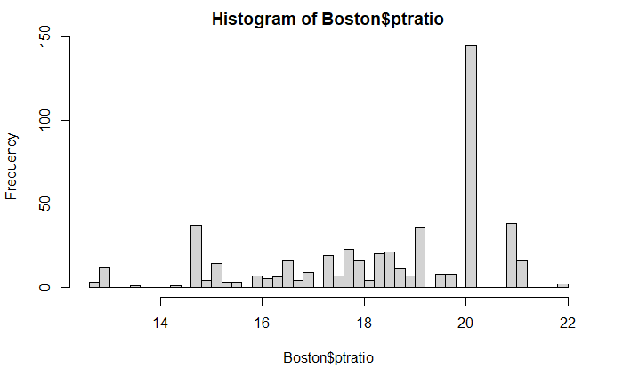

```r
hist(Boston$ptratio, breaks = 50)
```

```r
nrow(Boston[Boston$ptratio > 20, ])
```

```
[1] 201
```

5. How many of the suburbs in this data set bound the Charles river ?

```r
nrow(Boston[Boston$chas == 1, ])
```

```
[1] 35
```

6. What is the median pupil-teacher ratio among the towns in this data set ?

```r
median(Boston$ptratio)
```

```
[1] 19.05
```

7. Which suburb of Boston has lowest median value of owner-occupied homes ? What are the values of the other predictors for that suburb, and how do those values compare to the overall ranges for those predictors ?

```r
row.names(Boston[min(Boston$medv), ])
```

```
[1] "5"
```

```r
range(Boston$tax)
```

```
[1] 187 711
```

```r
Boston[min(Boston$medv), ]$tax
```

```
[1] 222
```

8. In this data set, how many of the suburbs average more than seven rooms per dwelling ? More than eight rooms per dwelling ?

```r
nrow(Boston[Boston$rm > 7, ])
```

```
[1] 64
```

```r
nrow(Boston[Boston$rm > 8, ])
```

```
[1] 13
```